# Self-Driving Car Engineer Nanodegree

## Project: Build a Traffic Sign Recognition Classifier

For the purpose of building this classifier a convolutional neural network model is employed. Convolutional Neural Networks (CNNs) are known to work well with image classification because they help to preserve the spatial arrangement of the pixels which is important when looking for certain patterns. The TensorFlow framework is used to build and run the CNN model.

## Step 0: Load The Data

```python
# Imports
import matplotlib.pyplot as plt
%matplotlib inline

import tensorflow as tf
import numpy as np
import cv2

import random
import pickle
```

```python
# Load pickled data
training_file   =  '../data/train.p'
validation_file =  '../data/valid.p'
testing_file    =  '../data/test.p'

with open(training_file, mode='rb') as f:
    train = pickle.load(f)
with open(validation_file, mode='rb') as f:
    valid = pickle.load(f)
with open(testing_file, mode='rb') as f:
    test = pickle.load(f)

X_train, y_train = train['features'], train['labels']
X_valid, y_valid = valid['features'], valid['labels']
X_test, y_test = test['features'], test['labels']
```

## Step 1: Dataset Summary & Exploration

The pickled data is a dictionary with 4 key/value pairs:

- `'features'` is a 4D array containing raw pixel data of the traffic sign images, (num examples, width, height, channels).
- `'labels'` is a 1D array containing the label/class id of the traffic sign. The file `signnames.csv` contains id -> name mappings for each id.
- `'sizes'` is a list containing tuples, (width, height) representing the original width and height the image.
- `'coords'` is a list containing tuples, (x1, y1, x2, y2) representing coordinates of a bounding box around the sign in the image. **THESE COORDINATES ASSUME THE ORIGINAL IMAGE. THE PICKLED DATA CONTAINS RESIZED VERSIONS (32 by 32) OF THESE IMAGES**

Complete the basic data summary below. Use python, numpy and/or pandas methods to calculate the data summary rather than hard coding the results. For example, the [pandas shape method](http://pandas.pydata.org/pandas-docs/stable/generated/pandas.DataFrame.shape.html) might be useful for calculating some of the summary results.

### Provide a Basic Summary of the Data Set Using Python, Numpy and/or Pandas

```python
# TODO: Number of training examples
n_train = len(X_train)

# TODO: Number of validation examples
n_validation = len(X_valid)

# TODO: Number of testing examples.
n_test = len(X_test)

# TODO: What's the shape of an traffic sign image?
image_shape = X_train[0].shape

# TODO: How many unique classes/labels there are in the dataset.
n_classes = len(set(y_train))

print("Number of training examples =", n_train)
print("Number of testing examples =", n_test)
print("Number of validation examples =", n_validation)
print("Image data shape =", image_shape)
print("Number of classes =", n_classes)
```

```
Number of training examples = 34799
Number of testing examples = 12630
Number of validation examples = 4410
Image data shape = (32, 32, 3)
Number of classes = 43
```

### Include an exploratory visualization of the dataset

Visualize the German Traffic Signs Dataset using the pickled file(s). This is open ended, suggestions include: plotting traffic sign images, plotting the count of each sign, etc.

The [Matplotlib](http://matplotlib.org/) [examples](http://matplotlib.org/examples/index.html) and [gallery](http://matplotlib.org/gallery.html) pages are a great resource for doing visualizations in Python.

**NOTE:** It's recommended you start with something simple first. If you wish to do more, come back to it after you've completed the rest of the sections. It can be interesting to look at the distribution of classes in the training, validation and test set. Is the distribution the same? Are there more examples of some classes than others?

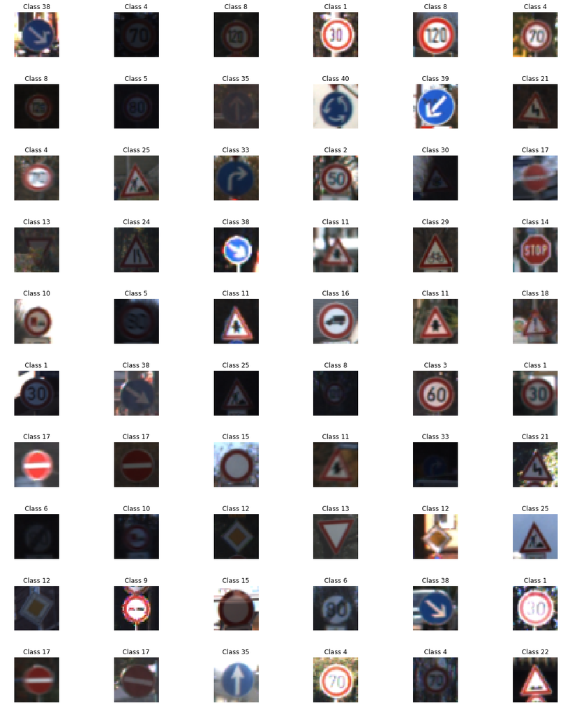

```python
### Data exploration visualization code goes here.
### Feel free to use as many code cells as needed.

fig, axs = plt.subplots(10,6, figsize=(20, 24))
fig.subplots_adjust(hspace = .6, wspace=.1)
axs = axs.ravel()

for i in range(60):
    index = random.randint(0, len(X_train))
    image = X_train[index].squeeze()
    axs[i].axis('off')
    message = 'Class {}'.format(y_train[index])
    axs[i].set_title(message)
    axs[i].imshow(image.squeeze())
```

### Display the list of Class ID's and Names

```python
import csv
with open('signnames.csv') as csv_file:
    csv_reader = csv.reader(csv_file, delimiter=',')
    sign_names = [(row[1]) for row in csv_reader]
    sign_names.pop(0)

for class_id, class_name in enumerate(sign_names):
    if not class_id % 10: print()
    print('Class {}   :   {}'.format(class_id, class_name))
```

```
Class 0   :   Speed limit (20km/h)
Class 1   :   Speed limit (30km/h)
Class 2   :   Speed limit (50km/h)
Class 3   :   Speed limit (60km/h)
Class 4   :   Speed limit (70km/h)
Class 5   :   Speed limit (80km/h)
Class 6   :   End of speed limit (80km/h)
Class 7   :   Speed limit (100km/h)
Class 8   :   Speed limit (120km/h)
Class 9   :   No passing

Class 10   :   No passing for vehicles over 3.5 metric tons
Class 11   :   Right-of-way at the next intersection
Class 12   :   Priority road
Class 13   :   Yield
Class 14   :   Stop
Class 15   :   No vehicles
Class 16   :   Vehicles over 3.5 metric tons prohibited
Class 17   :   No entry
Class 18   :   General caution
Class 19   :   Dangerous curve to the left

Class 20   :   Dangerous curve to the right
Class 21   :   Double curve
Class 22   :   Bumpy road
Class 23   :   Slippery road
Class 24   :   Road narrows on the right
Class 25   :   Road work
Class 26   :   Traffic signals
Class 27   :   Pedestrians
Class 28   :   Children crossing
Class 29   :   Bicycles crossing

Class 30   :   Beware of ice/snow
Class 31   :   Wild animals crossing
Class 32   :   End of all speed and passing limits
Class 33   :   Turn right ahead
Class 34   :   Turn left ahead
Class 35   :   Ahead only
Class 36   :   Go straight or right
Class 37   :   Go straight or left
Class 38   :   Keep right
Class 39   :   Keep left

Class 40   :   Roundabout mandatory
Class 41   :   End of no passing
Class 42   :   End of no passing by vehicles over 3.5 metric tons
```

### Class Distribution of Data

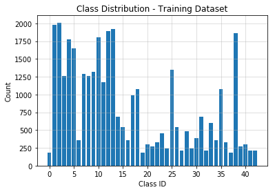

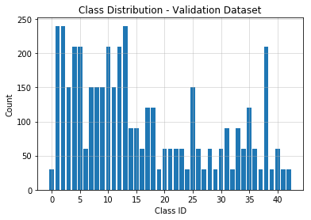

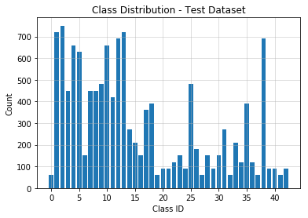

```python
uniques, counts = np.unique(y_train, return_counts=True)
plt.bar(uniques, counts)
plt.grid()
plt.title("Class Distribution - Training Dataset")
plt.xlabel('Class ID')
plt.ylabel('Count')
plt.xticks(np.arange(0, 43, 5))
plt.grid(which='minor', alpha=0.2)
plt.grid(which='major', alpha=0.5)
plt.show()

uniques, counts = np.unique(y_valid, return_counts=True)
plt.bar(uniques, counts)
plt.grid()
plt.title("Class Distribution - Validation Dataset")
plt.xlabel('Class ID')
plt.ylabel('Count')
plt.xticks(np.arange(0, 43, 5))
plt.grid(which='minor', alpha=0.2)
plt.grid(which='major', alpha=0.5)
plt.show()

uniques, counts = np.unique(y_test, return_counts=True)
plt.bar(uniques, counts)
plt.grid()
plt.title("Class Distribution - Test Dataset")
plt.xlabel('Class ID')
plt.ylabel('Count')
plt.xticks(np.arange(0, 43, 5))
plt.grid(which='minor', alpha=0.2)
plt.grid(which='major', alpha=0.5)
plt.show()
```

## Step 2: Design and Test a Model Architecture

Design and implement a deep learning model that learns to recognize traffic signs. Train and test your model on the [German Traffic Sign Dataset](http://benchmark.ini.rub.de/?section=gtsrb&subsection=dataset).

The LeNet-5 implementation shown in the classroom at the end of the CNN lesson is a solid starting point. You'll have to change the number of classes and possibly the preprocessing, but aside from that it's plug and play!

With the LeNet-5 solution from the lecture, you should expect a validation set accuracy of about 0.89. To meet specifications, the validation set accuracy will need to be at least 0.93. It is possible to get an even higher accuracy, but 0.93 is the minimum for a successful project submission.

There are various aspects to consider when thinking about this problem:

- Neural network architecture (is the network over or underfitting?)
- Play around preprocessing techniques (normalization, rgb to grayscale, etc)
- Number of examples per label (some have more than others).
- Generate fake data.

Here is an example of a [published baseline model on this problem](http://yann.lecun.com/exdb/publis/pdf/sermanet-ijcnn-11.pdf). It's not required to be familiar with the approach used in the paper but, it's good practice to try to read papers like these.

### Pre-process the Data Set (normalization, grayscale, etc.)

Minimally, the image data should be normalized so that the data has mean zero and equal variance. For image data, `(pixel - 128)/ 128` is a quick way to approximately normalize the data and can be used in this project.

Other pre-processing steps are optional. You can try different techniques to see if it improves performance.

Use the code cell (or multiple code cells, if necessary) to implement the first step of your project.

```python
def normalize_image(image_data):
    return  (image_data - 128.0) / 128.0
```

```python
### Preprocess the data here. It is required to normalize the data. Other preprocessing steps could include
### converting to grayscale, etc.

# normalize all the image data
X_train_norm = normalize_image(X_train)
X_valid_norm = normalize_image(X_valid)
X_test_norm  = normalize_image(X_test)
```

### Model Definition

```python
def LeNet(x):
    mu = 0
    sigma = 0.1

    ############################

    # Layer 1: Convolutional. Input = 32x32x3. Output = 28x28x6.
    conv1_W = tf.Variable(tf.truncated_normal(shape=(5, 5, 3, 6), mean = mu, stddev = sigma))
    conv1_b = tf.Variable(tf.zeros(6))
    conv1   = tf.nn.conv2d(x, conv1_W, strides=[1, 1, 1, 1], padding='VALID') + conv1_b
    # Activation.
    conv1 = tf.nn.relu(conv1)

    # Pooling. Input = 28x28x6. Output = 14x14x6.
    conv1 = tf.nn.max_pool(conv1, ksize=[1, 2, 2, 1], strides=[1, 2, 2, 1], padding='VALID')

    ############################

    # Layer 2: Convolutional. Output = 10x10x16.
    conv2_W = tf.Variable(tf.truncated_normal(shape=(5, 5, 6, 16), mean = mu, stddev = sigma))
    conv2_b = tf.Variable(tf.zeros(16))
    conv2   = tf.nn.conv2d(conv1, conv2_W, strides=[1, 1, 1, 1], padding='VALID') + conv2_b
    # Activation.
    conv2 = tf.nn.relu(conv2)

    # Pooling. Input = 10x10x16. Output = 5x5x16.
    conv2 = tf.nn.max_pool(conv2, ksize=[1, 2, 2, 1], strides=[1, 2, 2, 1], padding='VALID')

    ############################

    # Flatten. Input = 5x5x16. Output = 400.
    fc0   = flatten(conv2)

    # Layer 3: Fully Connected. Input = 400. Output = 120.
    fc1_W = tf.Variable(tf.truncated_normal(shape=(400, 120), mean = mu, stddev = sigma))
    fc1_b = tf.Variable(tf.zeros(120))
    fc1   = tf.matmul(fc0, fc1_W) + fc1_b
    # Activation.
    fc1    = tf.nn.relu(fc1)
    # Dropout
    fc1 = tf.nn.dropout(fc1, keep_prob)

    ############################

    # Layer 4: Fully Connected. Input = 120. Output = 84.
    fc2_W  = tf.Variable(tf.truncated_normal(shape=(120, 84), mean = mu, stddev = sigma))
    fc2_b  = tf.Variable(tf.zeros(84))
    fc2    = tf.matmul(fc1, fc2_W) + fc2_b
    # Activation.
    fc2    = tf.nn.relu(fc2)
    # Dropout
    fc2 = tf.nn.dropout(fc2, keep_prob)

    ############################

    # Layer 5: Fully Connected. Input = 84. Output = 43.
    fc3_W  = tf.Variable(tf.truncated_normal(shape=(84, 43), mean = mu, stddev = sigma))
    fc3_b  = tf.Variable(tf.zeros(43))
    logits = tf.matmul(fc2, fc3_W) + fc3_b

    return logits
```

```python
def MyNet(x):
    mu = 0
    sigma = 0.1

    ############################

    # Layer 1: Convolutional. Input = 32x32x3. Output = 28x28x24.
    conv1_W = tf.Variable(tf.truncated_normal(shape=(5, 5, 3, 24), mean = mu, stddev = sigma))
    conv1_b = tf.Variable(tf.zeros(24))
    conv1   = tf.nn.conv2d(x, conv1_W, strides=[1, 1, 1, 1], padding='VALID') + conv1_b
    # Activation.
    conv1 = tf.nn.relu(conv1)

    # Pooling. Input = 28x28x24. Output = 14x14x24.
    conv1 = tf.nn.max_pool(conv1, ksize=[1, 2, 2, 1], strides=[1, 2, 2, 1], padding='VALID')

    ############################

    # Layer 2: Convolutional. Input = 14x14x24. Output = 10x10x48.
    conv2_W = tf.Variable(tf.truncated_normal(shape=(5, 5, 24, 48), mean = mu, stddev = sigma))
    conv2_b = tf.Variable(tf.zeros(48))
    conv2   = tf.nn.conv2d(conv1, conv2_W, strides=[1, 1, 1, 1], padding='VALID') + conv2_b
    # Activation.
    conv2 = tf.nn.relu(conv2)

    # Pooling. Input = 10x10x48. Output = 5x5x48.
    conv2 = tf.nn.max_pool(conv2, ksize=[1, 2, 2, 1], strides=[1, 2, 2, 1], padding='VALID')

    ############################


   # Layer 3: Convolutional. Input = 5x5x48. Output = 1x1x128.
    conv3_W = tf.Variable(tf.truncated_normal(shape=(5, 5, 48, 128), mean = mu, stddev = sigma))
    conv3_b = tf.Variable(tf.zeros(128))
    conv3   = tf.nn.conv2d(conv2, conv3_W, strides=[1, 1, 1, 1], padding='VALID') + conv3_b
    # Activation.
    conv3 = tf.nn.relu(conv3)

    ############################


    # Flatten. Input = 1x1x128. Output = 128.
    fc0   = flatten(conv3)

    # Layer 4: Fully Connected. Input = 128. Output = 400.
    fc1_W = tf.Variable(tf.truncated_normal(shape=(128, 400), mean = mu, stddev = sigma))
    fc1_b = tf.Variable(tf.zeros(400))
    fc1   = tf.matmul(fc0, fc1_W) + fc1_b
    # Activation.
    fc1    = tf.nn.relu(fc1)
    # Dropout
    fc1 = tf.nn.dropout(fc1, keep_prob)

    ############################

    # Layer 5: Fully Connected. Input = 400. Output = 200.
    fc2_W  = tf.Variable(tf.truncated_normal(shape=(400, 200), mean = mu, stddev = sigma))
    fc2_b  = tf.Variable(tf.zeros(200))
    fc2    = tf.matmul(fc1, fc2_W) + fc2_b
    # Activation.
    fc2    = tf.nn.relu(fc2)
    # Dropout
    fc2 = tf.nn.dropout(fc2, keep_prob)

    ############################

    # Layer 6: Fully Connected. Input = 200. Output = 43.
    fc3_W  = tf.Variable(tf.truncated_normal(shape=(200, 43), mean = mu, stddev = sigma))
    fc3_b  = tf.Variable(tf.zeros(43))
    logits = tf.matmul(fc2, fc3_W) + fc3_b

    return logits
```

### Define Hyperparameters and Placeholders

```python
import tensorflow as tf
from tensorflow.contrib.layers import flatten
from sklearn.utils import shuffle

EPOCHS = 25
BATCH_SIZE = 128

learn_rate = 0.0005

IMAGE_HEIGHT = image_shape[0]
IMAGE_WIDTH = image_shape[1]
IMAGE_DEPTH = image_shape[2]

x = tf.placeholder(tf.float32, (None, 32, 32, 3))
y = tf.placeholder(tf.int32, (None))
keep_prob = tf.placeholder(tf.float32)
one_hot_y = tf.one_hot(y, 43)
```

### Training Pipeline

```python
#logits = LeNet(x)
logits = MyNet(x)

cross_entropy = tf.nn.softmax_cross_entropy_with_logits(labels=one_hot_y, logits=logits)
loss_operation = tf.reduce_mean(cross_entropy)
optimizer = tf.train.AdamOptimizer(learning_rate = learn_rate)
training_operation = optimizer.minimize(loss_operation)
```

### Model Evaluation

```python
correct_prediction = tf.equal(tf.argmax(logits, 1), tf.argmax(one_hot_y, 1))
accuracy_operation = tf.reduce_mean(tf.cast(correct_prediction, tf.float32))
saver = tf.train.Saver()

def evaluate(X_data, y_data):
    num_examples = len(X_data)
    total_accuracy = 0
    sess = tf.get_default_session()
    for offset in range(0, num_examples, BATCH_SIZE):
        batch_x, batch_y = X_data[offset:offset+BATCH_SIZE], y_data[offset:offset+BATCH_SIZE]
        accuracy = sess.run(accuracy_operation, feed_dict={x: batch_x, y: batch_y, keep_prob: 1.0})
        total_accuracy += (accuracy * len(batch_x))
    return total_accuracy / num_examples
```

### Train the Model

```python
with tf.Session() as sess:
    sess.run(tf.global_variables_initializer())
    num_examples = len(X_train)

    print("Training...")
    print()

    results = np.zeros((EPOCHS,4))

    for i in range(EPOCHS):
        train_accuracy = 0.0
        train_entropy = 0.0

        X_train_norm, y_train = shuffle(X_train_norm, y_train)
        for offset in range(0, num_examples, BATCH_SIZE):
            end = offset + BATCH_SIZE
            batch_x, batch_y = X_train_norm[offset:end], y_train[offset:end]
            _, entropy, accuracy = sess.run([training_operation, loss_operation, accuracy_operation], feed_dict={x: batch_x, y: batch_y, keep_prob: 0.45})

            train_accuracy += accuracy*BATCH_SIZE
            train_entropy += entropy*BATCH_SIZE

        train_accuracy /= num_examples
        train_entropy /= num_examples
        valid_accuracy, valid_entropy = sess.run([accuracy_operation, loss_operation], feed_dict={x: X_valid_norm, y: y_valid, keep_prob:1.0})

        results[i][0] = train_accuracy
        results[i][1] = train_entropy
        results[i][2] = valid_accuracy
        results[i][3] = valid_entropy

        print("EPOCH {} ...".format(i+1))
        print("Training Accuracy = {:.3f}".format(train_accuracy))
        print("Validation Accuracy = {:.3f}".format(valid_accuracy))
        print("Training Cross-Entropy = {:.3f}".format(train_entropy))
        print("Validation Cross-Entropy = {:.3f}".format(valid_entropy))
        print()

    saver.save(sess, './mynet')
    print("Model saved")
```

```
Training...

EPOCH 1 ...
Training Accuracy = 0.225
Validation Accuracy = 0.543
Training Cross-Entropy = 3.015
Validation Cross-Entropy = 1.743

EPOCH 2 ...
Training Accuracy = 0.634
Validation Accuracy = 0.820
Training Cross-Entropy = 1.253
Validation Cross-Entropy = 0.677

EPOCH 3 ...
Training Accuracy = 0.826
Validation Accuracy = 0.890
Training Cross-Entropy = 0.572
Validation Cross-Entropy = 0.406

EPOCH 4 ...
Training Accuracy = 0.902
Validation Accuracy = 0.909
Training Cross-Entropy = 0.331
Validation Cross-Entropy = 0.315

EPOCH 5 ...
Training Accuracy = 0.932
Validation Accuracy = 0.923
Training Cross-Entropy = 0.226
Validation Cross-Entropy = 0.292

EPOCH 6 ...
Training Accuracy = 0.956
Validation Accuracy = 0.933
Training Cross-Entropy = 0.157
Validation Cross-Entropy = 0.244

EPOCH 7 ...
Training Accuracy = 0.966
```

[output cut: 98 more lines]

```
Validation Cross-Entropy = 0.294

EPOCH 24 ...
Training Accuracy = 0.996
Validation Accuracy = 0.950
Training Cross-Entropy = 0.015
Validation Cross-Entropy = 0.289

EPOCH 25 ...
Training Accuracy = 0.995
Validation Accuracy = 0.958
Training Cross-Entropy = 0.021
Validation Cross-Entropy = 0.259

Model saved
```

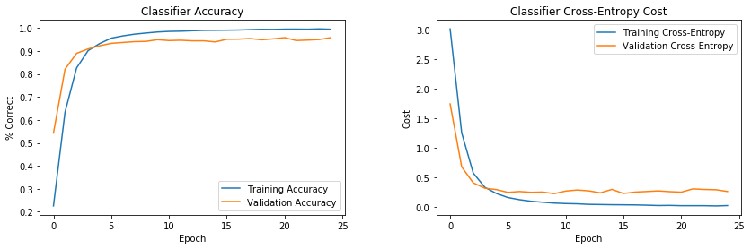

```python
fig, axs = plt.subplots(1,2, figsize=(14, 4))
fig.subplots_adjust(hspace=1.0, wspace=.3)
axs = axs.ravel()

axs[0].plot(results[:,0], label="Training Accuracy")
axs[0].plot(results[:,2], label="Validation Accuracy")
axs[0].set_title('Classifier Accuracy')
axs[0].set_xlabel('Epoch')
axs[0].set_ylabel('% Correct')
axs[0].legend()

axs[1].plot(results[:,1], label="Training Cross-Entropy")
axs[1].plot(results[:,3], label="Validation Cross-Entropy")
axs[1].set_title('Classifier Cross-Entropy Cost')
axs[1].set_xlabel('Epoch')
axs[1].set_ylabel('Cost')
axs[1].legend()
```

### Evaluate the Model Using the test Set

```python
with tf.Session() as sess:
    saver = tf.train.import_meta_graph('./mynet.meta')
    saver.restore(sess, "./mynet")

    test_accuracy = evaluate(X_test_norm, y_test)
    print("Test Accuracy = {:.3f}".format(test_accuracy))
```

```
INFO:tensorflow:Restoring parameters from ./mynet
Test Accuracy = 0.942
```

## Step 3: Test a Model on New Images

To give more insight into how the model is working, I have download pictures of German traffic signs from the web and will test my model's ability to predict the traffic sign type.

### Load and Output the Images

```
Image Shape: (32, 32, 3)
```

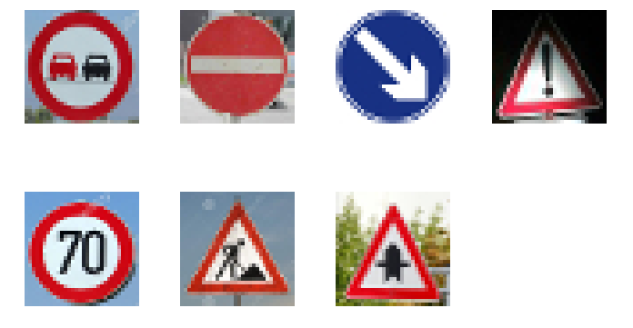

```python
import glob
import matplotlib.image as mpimg

fig, axs = plt.subplots(2,4, figsize=(12, 6))
fig.subplots_adjust(hspace = .6, wspace=.1)
axs = axs.ravel()

images = []

for i, img in enumerate(glob.glob('./TrafficSignPics/sSign*.jpg')):
    image = cv2.imread(img)
    axs[i].axis('off')
    axs[i].imshow(cv2.cvtColor(image.squeeze(), cv2.COLOR_BGR2RGB))
    images.append(image)


images = np.array(images)
images_norm = normalize_image(images)
print('Image Shape: {}'.format(images[0].shape))
_ = axs[7].axis('off')
```

### Predict the Sign Type for Each Image

Show the top 5 probabilities for each image based on running the logits through the Softmax function. Numbers in parentheses are the probability (percent) and the class number. For this we can make use of TensorFlow's top_k method.

```
INFO:tensorflow:Restoring parameters from ./mynet
```

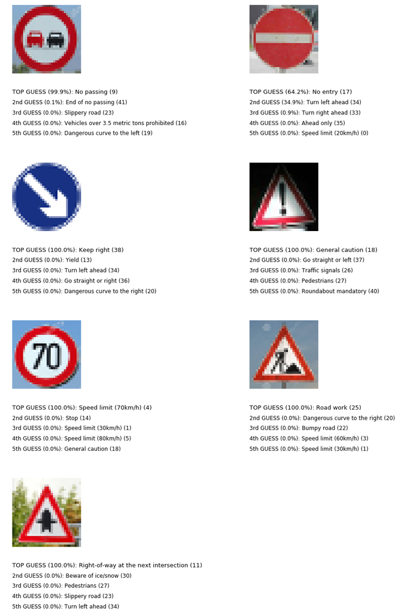

```python
softmax = tf.nn.softmax(logits)
top_k = tf.nn.top_k(softmax, k=5)

with tf.Session() as sess:
    sess.run(tf.global_variables_initializer())
    saver = tf.train.import_meta_graph('./mynet.meta')
    saver.restore(sess, "./mynet")
    my_softmax_logits = sess.run(softmax, feed_dict={x: images_norm, keep_prob: 1.0})
    my_top_k = sess.run(top_k, feed_dict={x: images_norm, keep_prob: 1.0})

fig, axs = plt.subplots(4,2, figsize=(13, 22))
fig.subplots_adjust(hspace=1.3, wspace=1.6)
axs = axs.ravel()

for i, image in enumerate(images):
    axs[i].axis('off')
    axs[i].imshow(cv2.cvtColor(image, cv2.COLOR_BGR2RGB))

    best_guess = my_top_k[1][i][0]
    second_guess = my_top_k[1][i][1]
    third_guess = my_top_k[1][i][2]
    fourth_guess = my_top_k[1][i][3]
    fifth_guess = my_top_k[1][i][4]

    message = "TOP GUESS ({:.1f}%): {} ({})".format(my_top_k[0][i][0]*100.0, sign_names[best_guess], best_guess)
    axs[i].text(0,-0.3, message, size=13, ha="left", transform=axs[i].transAxes)
    message = "2nd GUESS ({:.1f}%): {} ({})".format(my_top_k[0][i][1]*100.0, sign_names[second_guess], second_guess)
    axs[i].text(0,-0.45, message, size=12, ha="left", transform=axs[i].transAxes)
    message = "3rd GUESS ({:.1f}%): {} ({})".format(my_top_k[0][i][2]*100.0, sign_names[third_guess], third_guess)
    axs[i].text(0,-0.6, message, size=12, ha="left", transform=axs[i].transAxes)
    message = "4th GUESS ({:.1f}%): {} ({})".format(my_top_k[0][i][3]*100.0, sign_names[fourth_guess], fourth_guess)
    axs[i].text(0,-0.75, message, size=12, ha="left", transform=axs[i].transAxes)
    message = "5th GUESS ({:.1f}%): {} ({})".format(my_top_k[0][i][4]*100.0, sign_names[fifth_guess], fifth_guess)
    axs[i].text(0,-0.9, message, size=12, ha="left", transform=axs[i].transAxes)

_=axs[7].axis('off')
fig.savefig('TestFig.png')
```

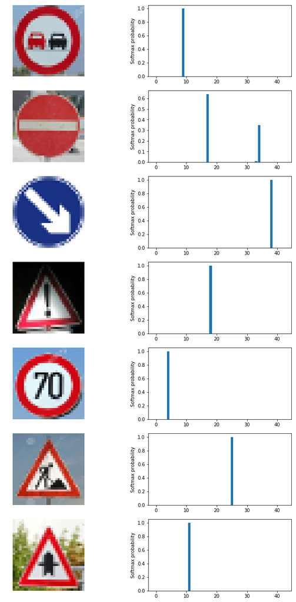

```python
fig, axs = plt.subplots(7,2, figsize=(12, 23))
axs = axs.ravel()

for i in range(len(my_softmax_logits)*2):
    if i%2 == 0:
        axs[i].axis('off')
        axs[i].imshow(cv2.cvtColor(images[i//2], cv2.COLOR_BGR2RGB))
    else:
        axs[i].bar(np.arange(n_classes), my_softmax_logits[(i-1)//2])
        axs[i].set_ylabel('Softmax probability')
```